# HDT3-Arboles de decision

### Variable GarageArea

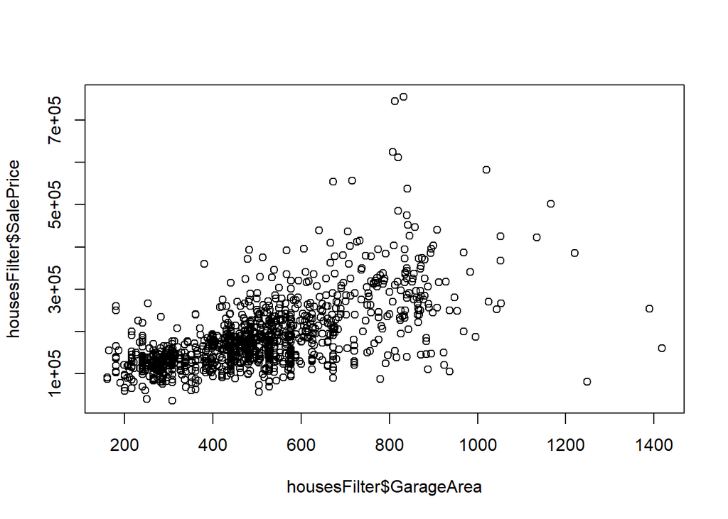

```r
plot(housesFilter$GarageArea, housesFilter$SalePrice)
```

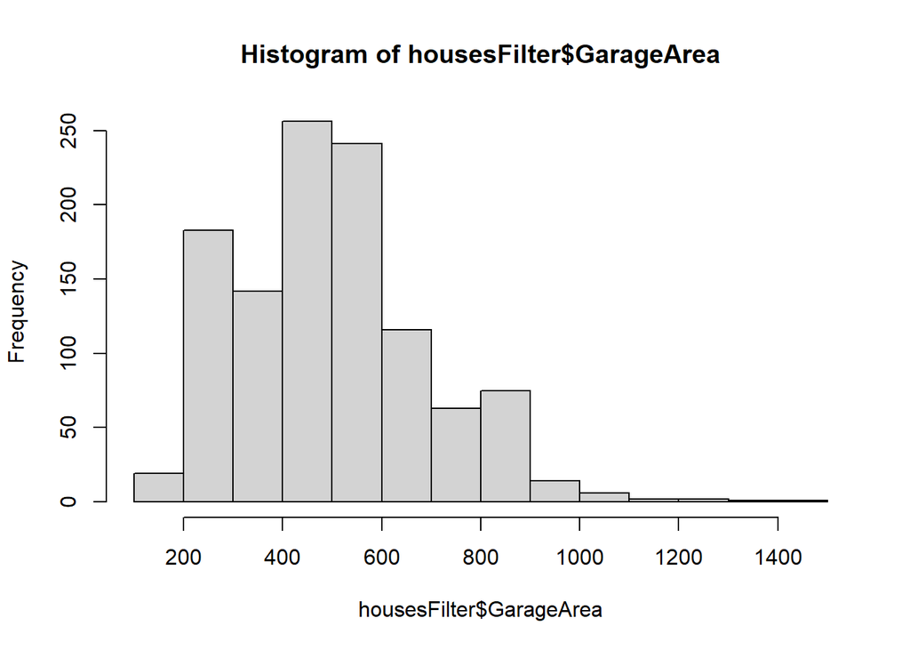

```r
hist(housesFilter$GarageArea)
```

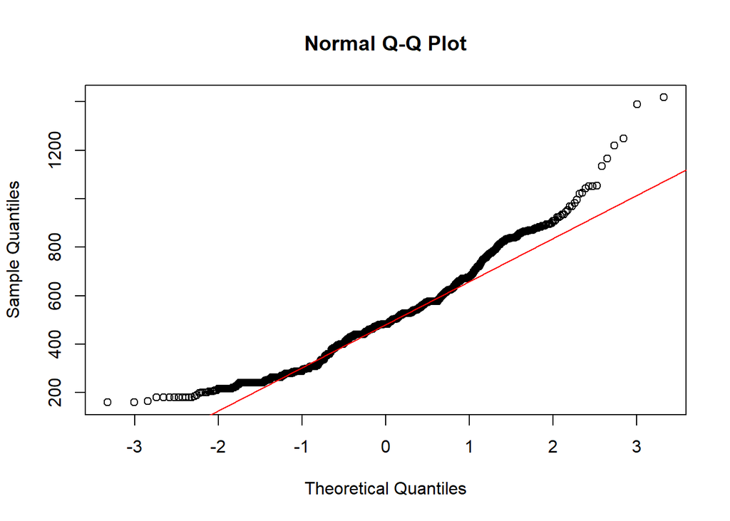

```r
qqnorm(housesFilter$GarageArea)
qqline(housesFilter$GarageArea, col='red')
```

##### Esta variable representa el tamaño del garage en pies cuadrados, se puede observar que existe una relacion bastate clara con el precio de venta.v

### Variable WoodDeckSF

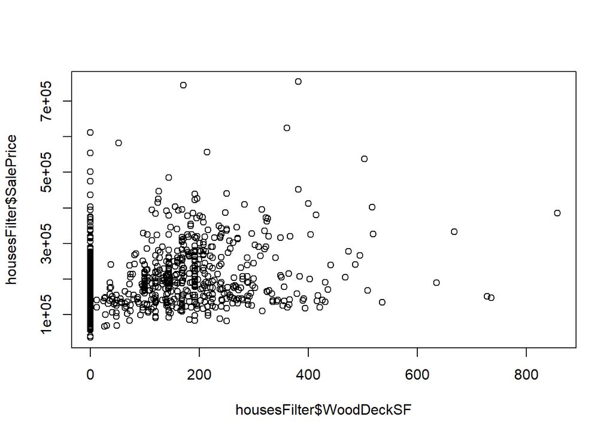

```r
plot(housesFilter$WoodDeckSF, housesFilter$SalePrice)
```

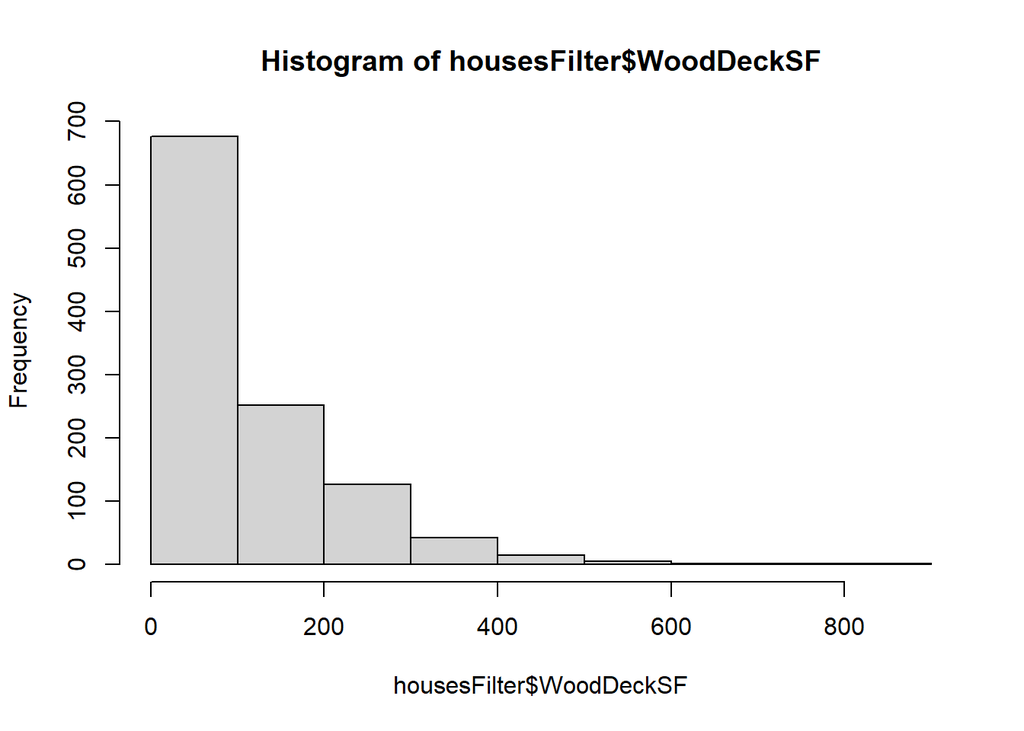

```r
hist(housesFilter$WoodDeckSF)
```

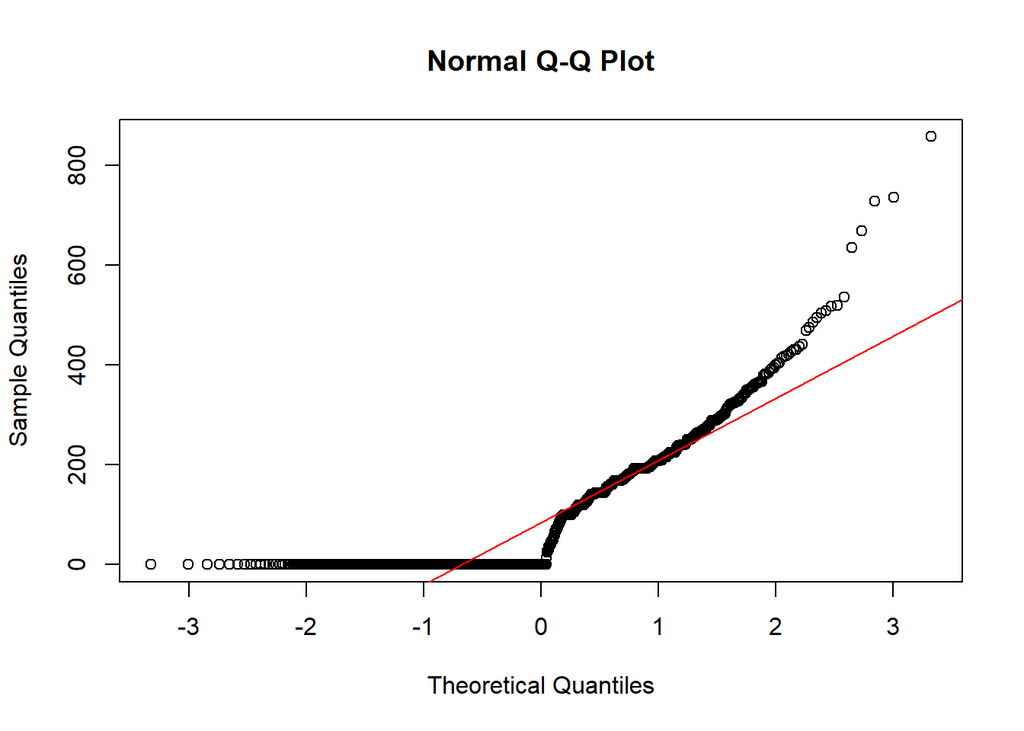

```r
qqnorm(housesFilter$WoodDeckSF)
qqline(housesFilter$WoodDeckSF, col='red')
```

##### Esta variable representa el area de la entrada con piso de madera en pies cuadrados, se puede observar que existe una relacion extraña al principio de grafica ya que agunos datos son cero, pero luego podemos observar como se va relacionando al precio de venta.